# Importing a river network into flume

For anything more than the simplest simulation, you will want something resembling a realistic river network. Creating this is quite tedious by hand, so this vignette will walk through various options for importing a network.

At minimum, a river network in `flume` consists of the following:

- A square (n by n) **adjacency matrix** (or **Topology**), which we call `A`. Each row/column represents a reach, and reaches are (roughly) equal in length. Note that `flume` itself treats all reaches as having equal length, so networks imported from a real river will necessarily be altered a little bit.
- The adjacency matrix is structured such that if `A[i,j] == 0`, then reach `i` and `j` are not adjacent. A nonzero value indicates that reach `i` is **upstream** of reach `j`.
- **Attributes**. The following attributes (with assumed units and dimensions) are required:
  - Cross-sectional area ($m^2$). A vector of length $n$.
  - Discharge ($m^3s^{-1}$). An $n$ by $t$ matrix, where $t$ is the number of time steps in the model. If using constant discharge, then a single column matrix or a vector.
  - Reach length ($m$). A single value (all reaches are identical length).
- Optionally:
  - x-y coordinates of a single point on each reach (e.g., the midpoint) (projected, in $m$); an $n$ by 2 matrix. Used for plotting the network

## Using the watershed package

We can use the package watershed to derive everything needed from a digital elevation model and a single (at least) measurement of discharge. This package relies on GRASS, which is not included, so be sure to follow the installation instructions before proceeding.

We will use the `kamp_dem` dataset provided with the `watershed` for an example. For more options on the procedure, there is also a [vignette](https://flee-group.github.io/watershed/watershed) available with the package.

```r
library(watershed)
library(raster)
library(sf)
library(Matrix)
library(flume)

data(kamp_dem)
thresh = 5e6
rlen = 5000
kamp = delineate(kamp_dem, outlet = NA, reach_len = rlen, threshold = thresh)
```

Next, we can build the adjacency matrix. This happens in two steps: first, we build a topology for all pixels, then we derive one for the reaches. We can also use this to create a vector layer of the stream.

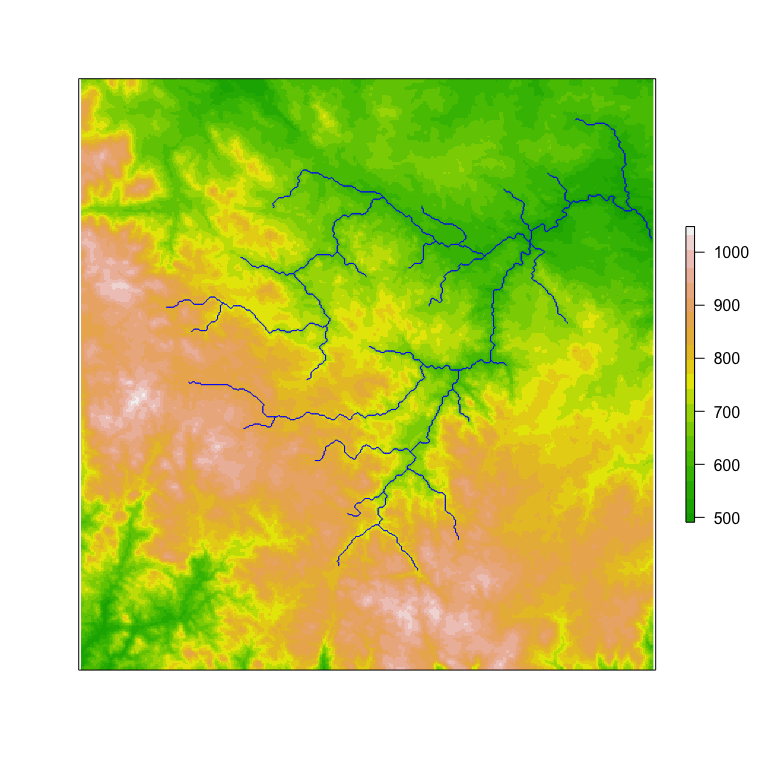

```r
Tp = pixel_topology(kamp)
A = reach_topology(kamp, Tp)

kv = vectorise_stream(kamp[["stream"]], Tp)
plot(kamp_dem, col=terrain.colors(20), axes = FALSE)
plot(st_geometry(kv), col='blue', add = TRUE)
```

Third we estimate discharge and hydraulic geometry for each reach. To do this, we need catchment area for each reach from the `catchment` function, as well as some calibration measurements, available in the `kamp_q` dataset.

```r
data(kamp_q)
kv$ca = catchment(kamp, type = 'reach', Tp = Tp)
## The points must be exactly on the stream to get reliable estimates of catchment area
## We drop anything with a catchment area below the threshold we used to make the network
## These points were on small streams and aren't useful for our purposes
kamp_q = st_snap(kamp_q, kv, tolerance=100)
kamp_q$ca = catchment(kamp, type = "points", y = st_coordinates(kamp_q))
kamp_q = subset(kamp_q, ca >= thresh)

## calibrate the discharge model and predict to the reach-level parameters
kv = cbind(kv, hydraulic_geometry(kamp_q$ca, kamp_q$discharge, kv$ca))
```

Finally we can use this information together to create a `river_network` for `flume`. I use a vector of zeros as the starting values for the state at the moment; what should be used will depend on the modelling needs. We provide the startpoint of each line using the `lwgeom` package.

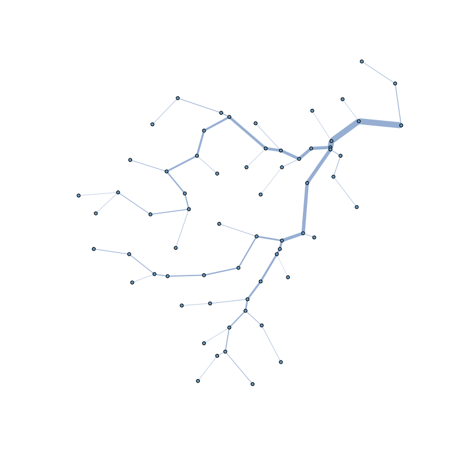

```r
layout =  st_coordinates(lwgeom::st_startpoint(kv))

## flume doesn't yet support units objects, so drop the units
kv$Q = units::drop_units(kv$Q)
kv$z = units::drop_units(kv$z)
kv$w = units::drop_units(kv$w)
rn = river_network(A, discharge = kv$Q, area = kv$z*kv$w, state = matrix(0, nrow=nrow(A), ncol=1),
              length = 2000, layout = layout)
plot(rn, edge.arrow.size=0, vertex.size=2, vertex.label=NA)
```

This network is also available with `flume` to use in further examples, it can be loaded with `data('kamp')` and accessed with `kamp[['network']]`.